# R Notebook

Brenden Eum

June 16, 2022

# 1 Introduction

This dataset will take the raw data and run preliminary analysis.

Start fresh, set seed, load libraries, set directories, and dictate whether you want analysis to occur quickly and verbose-ly.

```r
rm(list = ls())
seed = 1337
library(dplyr) #pipeline %>%
library(plotrix) #std.error
library(ggplot2) #plots... duh
library(grid) #combine plots
library(gridExtra) #more combining plots
library(ggsci) #I like the Futurama color palette <3
library(brms) #hierarchical regressions
library(runjags) #MCMC
library(effsize) #cohen's big fat d
library(latex2exp) #for fancy math stuffs in the plots
library(ggpubr) #column titles for grid.arrange plots

datadir <- '../data' #the only directory you need to set manually

quickly <- F #skip model fitting and use old estimates
show.reg.progress <- 0 #1=yes, 0=no
```

Useful functions.

```r
# estimate and return the mode of a distribution (in this case, the posterior)
estimate_mode <- function(x) {
  d <- density(x)
  return( d$x[which.max(d$y)] )
}

# estimate 95 HDI
estimate_hdi <- function(x, conf=.95) {
  lb <- 0 + (1-conf)/2
  ub <- 1 - (1-conf)/2
  d <- quantile(x, probs = c(lb,ub), na.rm = F,
           names = TRUE)
  return(d)
}
```

Settings for figures.

```r
ggplot <- function(...) ggplot2::ggplot(...) +
  theme_classic() +
  scale_color_npg() +
  scale_fill_npg() +
  coord_cartesian(expand=FALSE) +
  theme(
    legend.position="None",
    plot.margin = unit(c(.5,.5,.5,.5), "cm")
  )


linesize = 2
markersize = .1
ribbonalpha = 0.33
```

Settings for regressions.

```r
if (quickly==T) {refit="on_change"} else {refit="always"}

brm <- function(...)
  brms::brm(
    ...,
    iter = 6000, #samples from the posterior
    warmup = 3000, #part of a healthy workout
    chains = 3, #parallel
    cores = 3, #parallel
    backend = 'rstan',
    seed = seed, #based gaming
    refresh = show.reg.progress, #0 = dont show updates of sampling progress. 1 = what do you think...?
    file_refit = refit #if quickly is set to false, then re-run the regressions. o/w, pull reg results from temp files.
  )
```

# 2 Data cleaning

Combine all subjects’ datasets into one.

```r
raw_files <- list.files(path=datadir)
exploratory_data <- raw_files
#confirmatory_data <- raw_files[(floor(length(raw_files)/2)+1):length(raw_files)]

data <- data.frame()
for (file in raw_files) {
  raw_file <- read.csv(file = file.path(datadir, file))
  data <- bind_rows(data, raw_file)
}

data <- data[, names(data) != "X"]
```

Check how many observations are missing per subject. If it’s less a sufficient threshold (say below 5%), then let’s go ahead and drop them.

```r
subjects <- unique(data$subject)
temp <- c(1:length(subjects))
fail <- c(1:length(subjects))

for (ind in temp) {
  temp[ind] <- data[data$subject==subjects[ind],'response'] %>% #could be response, rt,
    is.na() %>%
    sum()
  temp[ind] <- temp[ind] / nrow(data[data$subject==subjects[ind],])
  fail[ind] <- (temp[ind] > 0.05)
}

if (sum(fail) != 0) {
  print("Some subjects missed more than 5% of all their trials. Go check who using 'fail'.")
} else {
  print("All subjects missed less than 5% of all their trials. Clear to proceed.")
  data <- na.omit(data)
}
```

```
## [1] "All subjects missed less than 5% of all their trials. Clear to proceed."
```

Data transformations. Save the cleaned dataset in the output folder.

```r
rownames(data) <- NULL #reset row indices (but trials variable will stay the same)

data <- data %>%
  mutate(
    subject = factor(subject) %>% as.numeric(), #change initials to numeric.
    choice = ifelse(response==2, 1,0), #choose red = 1, choose green = 0
    cue = ifelse(difficulty==52, 1,0) %>% factor(levels=c(0,1), labels=c("Invalid", "Valid")), #does stimulus favor red?
    correct = ifelse(difficulty>50, 1,0), #what is the correct answer?
    is_correct = ifelse(choice == correct, 1, 0) #was the subject's choice correct?
  )
```

Split the data into real data and sanity checks.

```r
sanitychecks <- data[data$difficulty!=48 & data$difficulty!=52,]
data <- data[data$difficulty==48 | data$difficulty==52,]
```

```r
subjects <- unique(sanitychecks$subject)
temp <- c(1:length(subjects))

for (ind in temp) {
  temp[ind] <- sanitychecks[sanitychecks$subject==subjects[ind],'is_correct'] %>%
    sum()
  temp[ind] <- temp[ind] / length(sanitychecks[sanitychecks$subject==subjects[ind],'is_correct'])
  temp[ind] <- (temp[ind] < 0.90)
}

if (sum(temp) != 0) {
  print("Some subjects failed more than 90% of sanity checks. Go check who using 'temp'.")
} else {
  print("All subjects passed more than 90% of sanity checks. Clear to proceed.")
}
```

```
## [1] "All subjects passed more than 90% of sanity checks. Clear to proceed."
```

```r
##############
## Exploratory
##############

source('set_e_dir.R')

save(data, file=file.path(outdir,"clean_data.RData"))
```

# 3 Analysis

## 3.1 Pr(red) wrt stimulus duration, grouped by cue type

A cue is valid if it favors red. A cue is invalid if it favors green.

Graph the probability of choosing red as the dominant color as a function of exogenous stimulus display time. Plot the mean and SE of the probabilities across subjects.

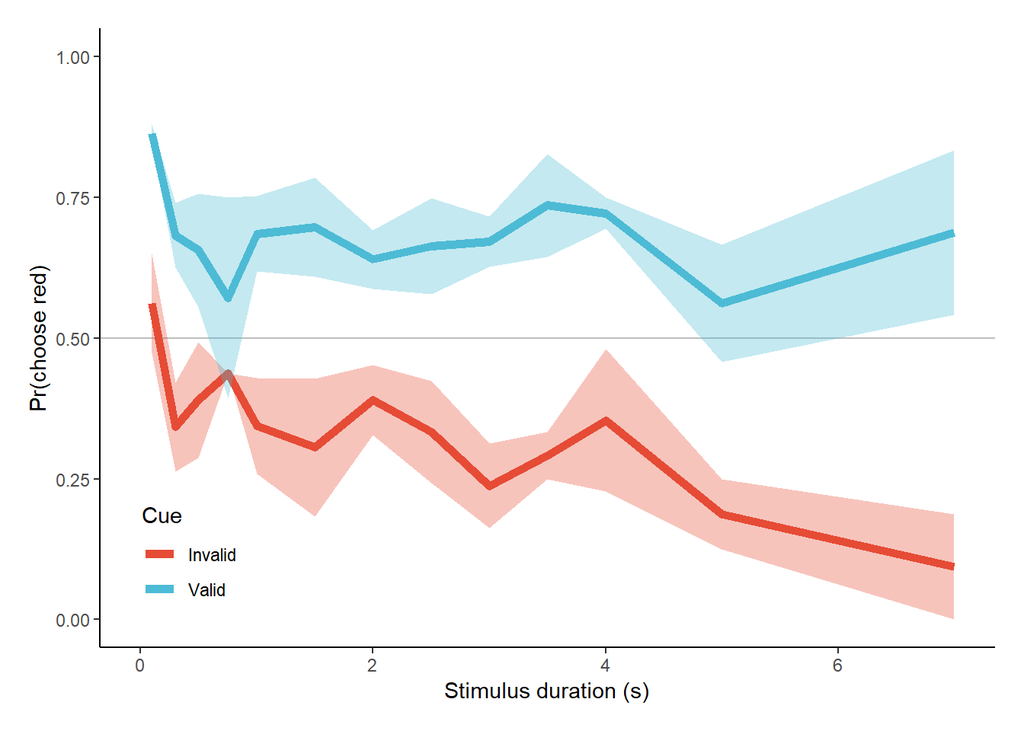

```r
##############
## Exploratory
##############

source('set_e_dir.R')
source('load_data.R')

pdata <- data %>%
  group_by(subject, stim_end, cue) %>%
  summarize(
    mean.choice = mean(choice)
  ) %>%
  ungroup() %>%
  group_by(stim_end, cue) %>%
  summarize(
    y = mean(mean.choice),
    se = std.error(mean.choice)
  )

p.choice <- ggplot(data=pdata, aes(x=stim_end, y=y, group=cue)) +
  geom_hline(
    yintercept=.5,
    color='grey'
  ) +
  geom_line(
    aes(color=cue),
    size=linesize
  ) +
  geom_ribbon(
    aes(ymin=y-se, ymax=y+se, fill=cue),
    size=linesize,
    alpha=ribbonalpha,
    show.legend=F
  ) +
  labs(
    y = "Pr(choose red)",
    x = "Stimulus duration (s)",
    color = "Cue"
  ) +
  coord_cartesian(
    xlim = c(0,NA),
    ylim = c(0,1)
  ) +
  theme(
    legend.position = c(.1,.15)
  )

p.choice
```

```r
ggsave(
  file.path(figdir, "fig_choice.pdf"),
  p.choice
)
```